# Practical Machine Learning Course Project

Igor Kaplanovic

September 19, 2014

## Loading and exploring data

- Load data.
- Remove columns with row numbers, user names and timestamps
- Remove near zero covariates and those with more than 80% missing values since these variables will not provide much power for prediction.
- Calculate correlations between each remaining feature to the response, `classe`. Use `spearman` rank based correlation because `classe` is a factor.
- Plot the two features that have highest correlation with `classe` and color with `classe` to see if we can separate response based on these features.

```r
# Loading given training data set
data <- read.csv("pml-training.csv", na.strings = c("NA", "#DIV/0!", ""))

# Removing firts 5 columns: X, user_name, raw_timestamp_part_1, raw_timestamp_part_2, cvtd_timestamp
data <- data[, -c(1, 2, 3, 4, 5)]


# Splitting data set into training and testing/cross-validation set
inTrain <- createDataPartition(data$classe, p = 0.7, list = FALSE)
training <- data[inTrain, ]
testing <- data[-inTrain, ]


# Removing near zero covariates
nearZeroVariance <- nearZeroVar(training, saveMetrics = TRUE)
training <- training[, !nearZeroVariance$nzv]

# Removing variables with more than 80% missing values
naVars <- sapply(colnames(training), function(x) if(sum(is.na(training[, x])) > 0.8*nrow(training)){return(T)}else{return(F)})
training <- training[, !naVars]

# Calculating correlations
cor <- abs(sapply(colnames(training[, -ncol(training)]), function(x) cor(as.numeric(training[, x]), as.numeric(training$classe), method = "spearman")))
```

```r
# Plotting predictors
summary(cor)
```

```
##    Min. 1st Qu.  Median    Mean 3rd Qu.    Max.
##  0.0014  0.0177  0.0550  0.0861  0.1370  0.3220
```

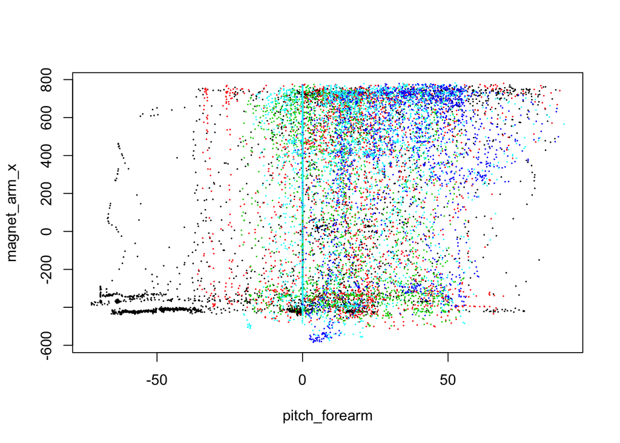

```r
plot(training[, names(which.max(cor))], training[, names(which.max(cor[-which.max(cor)]))], col = training$classe, pch = 19, cex = 0.1, xlab = names(which.max(cor)), ylab = names(which.max(cor[-which.max(cor)])))
```

The training set has **13737** samples and **53** potential predictors after filtering.

There doesn’t seem to be any strong predictors that correlates with `classe` well and linear regression model is probably not suitable in this case. Boosting and random forests algorithms may generate more robust predictions for our data.

## Boosting model

- Fit model with boosting algorithm and 10-fold cross validation to predict `classe` with all other predictors.
- Plot accuracy of this model on the scale `[0.75, 1]`.

```r
set.seed(123)
boostFit <- train(classe ~ ., method = "gbm", data = training, verbose = FALSE, trControl = trainControl(method = "cv", number = 10))
```

```r
boostFit
```

```
## Stochastic Gradient Boosting
##
## 13737 samples
##    53 predictor
##     5 classes: 'A', 'B', 'C', 'D', 'E'
##
## No pre-processing
## Resampling: Cross-Validated (10 fold)
##
## Summary of sample sizes: 12364, 12364, 12362, 12363, 12365, 12362, ...
##
## Resampling results across tuning parameters:
##
##   interaction.depth  n.trees  Accuracy  Kappa  Accuracy SD  Kappa SD
##   1                   50      0.8       0.7    0.008        0.010
##   1                  100      0.8       0.8    0.009        0.012
##   1                  150      0.9       0.8    0.007        0.008
##   2                   50      0.9       0.9    0.008        0.010
##   2                  100      0.9       0.9    0.006        0.008
##   2                  150      1.0       1.0    0.006        0.008
##   3                   50      0.9       0.9    0.006        0.008
##   3                  100      1.0       1.0    0.006        0.008
##   3                  150      1.0       1.0    0.003        0.004
##
## Tuning parameter 'shrinkage' was held constant at a value of 0.1
## Accuracy was used to select the optimal model using  the largest value.
## The final values used for the model were n.trees = 150,
##  interaction.depth = 3 and shrinkage = 0.1.
```

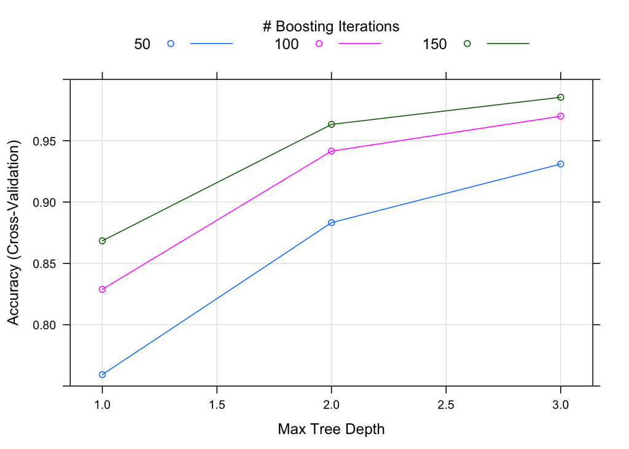

```r
plot(boostFit, ylim = c(0.75, 1))
```

The boosting algorithm generated a good model with **accuracy = 0.985**.

## Random forests model

- Fit model with random forests algorithm and 10-fold cross validation to predict `classe` with all other predictors.
- Plot accuracy of the model on the scale `[0.9, 1]`.

```r
set.seed(123)
rfFit <- train(classe ~ ., method = "rf", data = training, importance = TRUE, trControl = trainControl(method = "cv", number = 10))
```

```r
rfFit
```

```
## Random Forest
##
## 13737 samples
##    53 predictor
##     5 classes: 'A', 'B', 'C', 'D', 'E'
##
## No pre-processing
## Resampling: Cross-Validated (10 fold)
##
## Summary of sample sizes: 12363, 12364, 12363, 12364, 12364, 12362, ...
##
## Resampling results across tuning parameters:
##
##   mtry  Accuracy  Kappa  Accuracy SD  Kappa SD
##    2    1         1      0.002        0.002
##   27    1         1      0.001        0.001
##   53    1         1      0.003        0.004
##
## Accuracy was used to select the optimal model using  the largest value.
## The final value used for the model was mtry = 27.
```

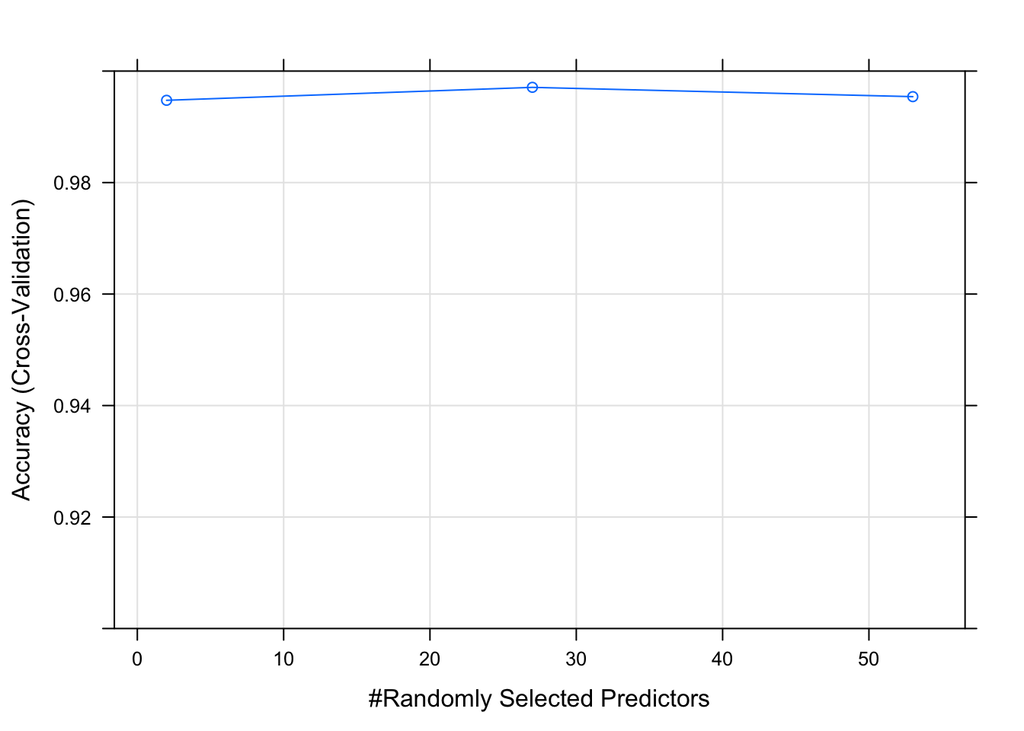

```r
plot(rfFit, ylim = c(0.9, 1))
```

The random forests algorithm generated a very accurate model with **accuracy close to 1**. Compared to boosting model, this model generally has better performance in terms of accuracy as seen from the plots.

## Final model

- Comparing model accuracy of the two models generated, random forests and boosting, random forests model has overall better accuracy.
- The final random forests model contains 500 trees with 27 variables tried at each split. The five most important predictors in this model are num_window, roll_belt, pitch_forearm, magnet_dumbbell_z, pitch_belt.
- Estimated **out of sample error rate** for the random forests model is **0.18%** as reported by the final model.
- Show confusion matrix for predictions on testing set.

```r
# Final model
rfFit$finalModel
```

```
##
## Call:
##  randomForest(x = x, y = y, mtry = param$mtry, importance = TRUE)
##                Type of random forest: classification
##                      Number of trees: 500
## No. of variables tried at each split: 27
##
##         OOB estimate of  error rate: 0.18%
## Confusion matrix:
##      A    B    C    D    E class.error
## A 3904    1    0    0    1    0.000512
## B    7 2649    2    0    0    0.003386
## C    0    2 2393    1    0    0.001252
## D    0    0    7 2245    0    0.003108
## E    0    0    0    4 2521    0.001584
```

```r
# Calculating predictions on testing set
predictions <- predict(rfFit, testing)

#Calculating confusion matrix on testing set
confusionMatrix(predictions, testing$classe)
```

```
## Confusion Matrix and Statistics
##
##           Reference
## Prediction    A    B    C    D    E
##          A 1674    1    0    0    0
##          B    0 1138    2    0    0
##          C    0    0 1024    2    0
##          D    0    0    0  961    0
##          E    0    0    0    1 1082
##
## Overall Statistics
##
##                Accuracy : 0.999
##                  95% CI : (0.998, 1)
##     No Information Rate : 0.284
##     P-Value [Acc > NIR] : <2e-16
##
##                   Kappa : 0.999
##  Mcnemar's Test P-Value : NA
##
## Statistics by Class:
##
##                      Class: A Class: B Class: C Class: D Class: E
## Sensitivity             1.000    0.999    0.998    0.997    1.000
## Specificity             1.000    1.000    1.000    1.000    1.000
## Pos Pred Value          0.999    0.998    0.998    1.000    0.999
## Neg Pred Value          1.000    1.000    1.000    0.999    1.000
## Prevalence              0.284    0.194    0.174    0.164    0.184
## Detection Rate          0.284    0.193    0.174    0.163    0.184
## Detection Prevalence    0.285    0.194    0.174    0.163    0.184
## Balanced Accuracy       1.000    0.999    0.999    0.998    1.000
```

## Prediction on unseen test set

- Predict the answers and save the results for automatic grader.

```r
# Loading unseen test data
testingUnseen <- read.csv("pml-testing.csv", na.strings = c("NA", "#DIV/0!", ""))

# Prediction
answers <- as.character(predict(rfFit, testingUnseen))
answers
```

```
##  [1] "B" "A" "B" "A" "A" "E" "D" "B" "A" "A" "B" "C" "B" "A" "E" "E" "A"
## [18] "B" "B" "B"
```

```r
# Writting prediction files
pml_write_files = function(x){
  n = length(x)
  for(i in 1:n){
    filename = paste0("problem_id_", i, ".txt")
    write.table(x[i], file = filename, quote = FALSE, row.names = FALSE, col.names = FALSE)
  }
}
pml_write_files(answers)
```